# KHÁM PHÁ DỮ LIỆU

Dữ liệu chứa trong file `tips.csv` chứa thông tin tiền tip của khách hàng tại một nhà hàng. Dữ liệu có các thông tin sau:

- `total_bill`: tổng hoá đơn (USD)
- `tip`: tiền tip/ tiền boa (USD)
- `sex`: giới tính người thanh toán hóa đơn
- `smoker`: có hút thuốc hay không
- `day`: ngày trong tuần
- `time`: thời gian dùng bữa(buổi sáng, buổi trưa, buổi tối)
- `size`: số lượng người tham gia

Bạn hãy thực hiện thống kê mô tả để tìm hiểu về hành vi tip của khách hàng tại nhà hàng

## HIỂU DỮ LIỆU

1. Đọc dữ liệu
2. Xoá cột `Unnamed: 0`
3. Cho biết dữ liệu có bao nhiêu dòng, bao nhiêu thuộc tính.
4. Trong các thuộc tính, thuộc tính nào là thuộc tính phân loại, thuộc tính nào là thuộc tính định lượng
5. Có bao nhiêu nam, bao nhiêu nữ. Tỷ lệ bao nhiêu?
6. Có bao nhiêu người hút thuốc. Tỷ lệ bao nhiêu?
7. Ngày nào trong tuần khách hàng hay đến dùng bữa nhất. Tỷ lệ bao nhiêu?
8. Nhà hàng phục vụ bữa ăn nào nhiều nhất (Breakfast, Lunch, Dinner)?
9. Nhóm khách hàng dùng bữa tại nhà hàng nhiều nhất là bao nhiêu người?
10. Trung bình trong một bữa ăn nhà hàng phục vụ mấy khách?

```python
import pandas as pd
import numpy as np

# 1. Đọc dữ liệu
df = pd.read_csv('data/tips.csv')


df = df.drop('Unnamed: 0', axis=1)

print("Dữ liệu sau khi đọc:")
print(df.head())
print("\n" + "="*50)

# 3. Cho biết dữ liệu có bao nhiêu dòng, bao nhiêu thuộc tính
print(f"3. Dữ liệu có {df.shape[0]} dòng và {df.shape[1]} thuộc tính")
print("\n" + "="*50)

# 4. Phân loại thuộc tính
# print("4. Phân loại thuộc tính:")
# print("Thuộc tính định lượng:", ['total_bill', 'tip', 'size'])
# print("Thuộc tính phân loại:", ['sex', 'smoker', 'day', 'time'])
# # ...existing code...
quantitative_cols = df.select_dtypes(include=[np.number]).columns.tolist()
categorical_cols = df.select_dtypes(include=['object', 'category']).columns.tolist()
print("Thuộc tính định lượng:", quantitative_cols)
print("Thuộc tính phân loại:", categorical_cols)
# ...existing code...
print("\n" + "="*50)

# 5. Thống kê giới tính
print("5. Thống kê giới tính:")
sex_counts = df['sex'].value_counts()
sex_ratio = df['sex'].value_counts(normalize=True) * 100
print(f"Nam: {sex_counts.get('Male', 0)} người ({sex_ratio.get('Male', 0):.1f}%)")
print(f"Nữ: {sex_counts.get('Female', 0)} người ({sex_ratio.get('Female', 0):.1f}%)")
print("\n" + "="*50)

# 6. Thống kê người hút thuốc
print("6. Thống kê hút thuốc:")
smoker_counts = df['smoker'].value_counts()
smoker_ratio = df['smoker'].value_counts(normalize=True) * 100
print(f"Hút thuốc: {smoker_counts.get('Yes', 0)} người ({smoker_ratio.get('Yes', 0):.1f}%)")
print(f"Không hút thuốc: {smoker_counts.get('No', 0)} người ({smoker_ratio.get('No', 0):.1f}%)")
print("\n" + "="*50)

# 7. Ngày nào khách hàng hay đến nhất
print("7. Thống kê theo ngày trong tuần:")
day_counts = df['day'].value_counts()
day_ratio = df['day'].value_counts(normalize=True) * 100
print("Thứ tự từ nhiều đến ít:")
for day in day_counts.index:
    print(f"{day}: {day_counts[day]} lượt ({day_ratio[day]:.1f}%)")
print(f"Ngày khách đến nhiều nhất: {day_counts.index[0]}")
print("\n" + "="*50)

# 8. Bữa ăn nào được phục vụ nhiều nhất
print("8. Thống kê theo bữa ăn:")
time_counts = df['time'].value_counts()
time_ratio = df['time'].value_counts(normalize=True) * 100
print("Thứ tự từ nhiều đến ít:")
for time_meal in time_counts.index:
    print(f"{time_meal}: {time_counts[time_meal]} lượt ({time_ratio[time_meal]:.1f}%)")
print(f"Bữa ăn được phục vụ nhiều nhất: {time_counts.index[0]}")
print("\n" + "="*50)

# 9. Nhóm khách hàng dùng bữa nhiều nhất
print("9. Thống kê theo kích thước nhóm:")
size_counts = df['size'].value_counts().sort_index()
size_ratio = df['size'].value_counts(normalize=True).sort_index() * 100
print("Thống kê theo số người:")
for size in size_counts.index:
    print(f"{size} người: {size_counts[size]} lượt ({size_ratio[size]:.1f}%)")
most_common_size = df['size'].value_counts().index[0]
print(f"Nhóm khách hàng dùng bữa nhiều nhất: {most_common_size} người")
print("\n" + "="*50)

# 10. Trung bình số khách trong một bữa ăn
print("10. Trung bình số khách trong một bữa ăn:")
avg_size = df['size'].mean()
print(f"Trung bình: {avg_size:.2f} khách/bữa")
```

```
Dữ liệu sau khi đọc:
   total_bill   tip     sex smoker  day    time  size
0       16.99  1.01  Female     No  Sun  Dinner     2
1       10.34  1.66    Male     No  Sun  Dinner     3
2       21.01  3.50    Male     No  Sun  Dinner     3
3       23.68  3.31    Male     No  Sun  Dinner     2
4       24.59  3.61  Female     No  Sun  Dinner     4

==================================================
3. Dữ liệu có 244 dòng và 7 thuộc tính

==================================================
Thuộc tính định lượng: ['total_bill', 'tip', 'size']
Thuộc tính phân loại: ['sex', 'smoker', 'day', 'time']

==================================================
5. Thống kê giới tính:
Nam: 157 người (64.3%)
Nữ: 87 người (35.7%)

==================================================
6. Thống kê hút thuốc:
Hút thuốc: 93 người (38.1%)
Không hút thuốc: 151 người (61.9%)

==================================================
7. Thống kê theo ngày trong tuần:
Thứ tự từ nhiều đến ít:
Sat: 87 lượt (35.7%)
Sun: 76 lượt (31.1%)
Thur: 62 lượt (25.4%)
Fri: 19 lượt (7.8%)
Ngày khách đến nhiều nhất: Sat

==================================================
8. Thống kê theo bữa ăn:
Thứ tự từ nhiều đến ít:
Dinner: 176 lượt (72.1%)
Lunch: 68 lượt (27.9%)
Bữa ăn được phục vụ nhiều nhất: Dinner

==================================================
9. Thống kê theo kích thước nhóm:
Thống kê theo số người:
1 người: 4 lượt (1.6%)
2 người: 156 lượt (63.9%)
3 người: 38 lượt (15.6%)
4 người: 37 lượt (15.2%)
5 người: 5 lượt (2.0%)
6 người: 4 lượt (1.6%)
Nhóm khách hàng dùng bữa nhiều nhất: 2 người

==================================================
10. Trung bình số khách trong một bữa ăn:
Trung bình: 2.57 khách/bữa
```

## YẾU TỐ ẢNH HƯỞNG ĐẾN TIỀN TIP

Trong phần này, chúng ta thử tìm hiểu về tiền tip tại nhà hàng và các yếu tố có thể ảnh hưởng đến nó

1. Tỷ lệ nhận được tiền tip của nhà hàng là bao nhiêu?
2. Tỷ lệ tiền tip trên tổng hóa đơn là bao nhiêu?
3. Giữa nam và nữ ai tip nhiều tiền hơn, ai tip thường xuyên hơn?
4. Giữa người hút thuốc và người không hút thuốc ai tip nhiều tiền hơn, ai tip thường xuyên hơn?
5. Thống kê tổng số tiền tip nhận được theo ngày.

```python
# YẾU TỐ ẢNH HƯỞNG ĐẾN TIỀN TIP

print("YẾU TỐ ẢNH HƯỞNG ĐẾN TIỀN TIP")
print("="*50)

# 1. Tỷ lệ nhận được tiền tip của nhà hàng
print("1. Tỷ lệ nhận được tiền tip:")
tip_received = (df['tip'] > 0).sum()
total_customers = len(df)
tip_rate = (tip_received / total_customers) * 100
print(f"Số khách tip: {tip_received}/{total_customers}")
print(f"Tỷ lệ nhận tip: {tip_rate:.1f}%")
print("\n" + "="*50)

# 2. Tỷ lệ tiền tip trên tổng hóa đơn
print("2. Tỷ lệ tiền tip trên tổng hóa đơn:")
df['tip_percentage'] = (df['tip'] / df['total_bill']) * 100
avg_tip_percentage = df['tip_percentage'].mean()
median_tip_percentage = df['tip_percentage'].median()
print(f"Tỷ lệ tip trung bình: {avg_tip_percentage:.2f}%")
print(f"Tỷ lệ tip trung vị: {median_tip_percentage:.2f}%")
print("\n" + "="*50)

# 3. So sánh tip giữa nam và nữ
print("3. So sánh tip giữa nam và nữ:")
tip_by_sex = df.groupby('sex').agg({
    'tip': ['mean', 'sum', 'count'],
    'tip_percentage': 'mean'
}).round(2)
print("Bảng thống kê tip_by_sex:")
print(tip_by_sex)

print("Tiền tip trung bình:")
print(f"Nam: ${tip_by_sex.loc['Male', ('tip', 'mean')]:.2f}")
print(f"Nữ: ${tip_by_sex.loc['Female', ('tip', 'mean')]:.2f}")

print("\nTổng tiền tip:")
print(f"Nam: ${tip_by_sex.loc['Male', ('tip', 'sum')]:.2f}")
print(f"Nữ: ${tip_by_sex.loc['Female', ('tip', 'sum')]:.2f}")

print("\nTỷ lệ tip trung bình:")
print(f"Nam: {tip_by_sex.loc['Male', ('tip_percentage', 'mean')]:.2f}%")
print(f"Nữ: {tip_by_sex.loc['Female', ('tip_percentage', 'mean')]:.2f}%")
print("\n" + "="*50)

# 4. So sánh tip giữa người hút thuốc và không hút thuốc
print("4. So sánh tip giữa người hút thuốc và không hút thuốc:")
tip_by_smoker = df.groupby('smoker').agg({
    'tip': ['mean', 'sum', 'count'],
    'tip_percentage': 'mean'
}).round(2)
print("Bảng thống kê tip_by_smoker:")
print(tip_by_smoker)

print("Tiền tip trung bình:")
print(f"Hút thuốc: ${tip_by_smoker.loc['Yes', ('tip', 'mean')]:.2f}")
print(f"Không hút thuốc: ${tip_by_smoker.loc['No', ('tip', 'mean')]:.2f}")

print("\nTổng tiền tip:")
print(f"Hút thuốc: ${tip_by_smoker.loc['Yes', ('tip', 'sum')]:.2f}")
print(f"Không hút thuốc: ${tip_by_smoker.loc['No', ('tip', 'sum')]:.2f}")

print("\nTỷ lệ tip trung bình:")
print(f"Hút thuốc: {tip_by_smoker.loc['Yes', ('tip_percentage', 'mean')]:.2f}%")
print(f"Không hút thuốc: {tip_by_smoker.loc['No', ('tip_percentage', 'mean')]:.2f}%")
print("\n" + "="*50)

# 5. Thống kê tổng số tiền tip theo ngày
print("5. Tổng số tiền tip theo ngày:")
tip_by_day = df.groupby('day').agg({
    'tip': ['sum', 'mean', 'count']
}).round(2)
print("Bảng thống kê tip_by_day:")
print(tip_by_day)
# Sắp xếp theo thứ tự ngày trong tuần
day_order = ['Sun', 'Mon', 'Tue', 'Wed', 'Thur', 'Fri', 'Sat']
tip_by_day = tip_by_day.reindex([day for day in day_order if day in tip_by_day.index])
print(tip_by_day)
print("\n" + "="*50)
print("Thống kê chi tiết:")
for day in tip_by_day.index:
    total_tip = tip_by_day.loc[day, ('tip', 'sum')]
    avg_tip = tip_by_day.loc[day, ('tip', 'mean')]
    count = tip_by_day.loc[day, ('tip', 'count')]
    print(f"{day}: Tổng ${total_tip:.2f} | TB ${avg_tip:.2f} | {count} lượt")

print(f"\nNgày có tổng tip cao nhất: {tip_by_day[('tip', 'sum')].idxmax()} (${tip_by_day[('tip', 'sum')].max():.2f})")
print(f"Ngày có tip trung bình cao nhất: {tip_by_day[('tip', 'mean')].idxmax()} (${tip_by_day[('tip', 'mean')].max():.2f})")
```

```
YẾU TỐ ẢNH HƯỞNG ĐẾN TIỀN TIP
==================================================
1. Tỷ lệ nhận được tiền tip:
Số khách tip: 244/244
Tỷ lệ nhận tip: 100.0%

==================================================
2. Tỷ lệ tiền tip trên tổng hóa đơn:
Tỷ lệ tip trung bình: 16.08%
Tỷ lệ tip trung vị: 15.48%

==================================================
3. So sánh tip giữa nam và nữ:
Bảng thống kê tip_by_sex:
         tip               tip_percentage
        mean     sum count           mean
sex
Female  2.83  246.51    87          16.65
Male    3.09  485.07   157          15.77
Tiền tip trung bình:
Nam: $3.09
Nữ: $2.83

Tổng tiền tip:
Nam: $485.07
Nữ: $246.51

Tỷ lệ tip trung bình:
Nam: 15.77%
Nữ: 16.65%

==================================================
4. So sánh tip giữa người hút thuốc và không hút thuốc:
Bảng thống kê tip_by_smoker:
         tip               tip_percentage
        mean     sum count           mean
smoker
No      2.99  451.77   151          15.93
Yes     3.01  279.81    93          16.32
Tiền tip trung bình:
```

[output cut: 23 more lines]

```
day
Sun   247.39  3.26    76
Thur  171.83  2.77    62
Fri    51.96  2.73    19
Sat   260.40  2.99    87

==================================================
Thống kê chi tiết:
Sun: Tổng $247.39 | TB $3.26 | 76 lượt
Thur: Tổng $171.83 | TB $2.77 | 62 lượt
Fri: Tổng $51.96 | TB $2.73 | 19 lượt
Sat: Tổng $260.40 | TB $2.99 | 87 lượt

Ngày có tổng tip cao nhất: Sat ($260.40)
Ngày có tip trung bình cao nhất: Sun ($3.26)
```

# TRỰC QUAN DỮ LIỆU

Để dễ hình dung, bạn hãy trực quan với một số câu hỏi sau đây:

1. Vẽ đồ thị thể hiện tổng tiền tip theo ngày
2. Vẽ đồ thị thể hiện tổng tiền tip theo bữa ăn (time)
3. Vẽ đồ thị histogram của tổng hoá đơn
4. Vẽ đồ thị boxplot của tổng hoá đơn
5. Vẽ đồ thị để kiểm tra sự liên quan giữa tổng hoá đơn và tiền tip.
6. So sánh số tiền mà khách hàng đã chi giữa các ngày trong tuần.

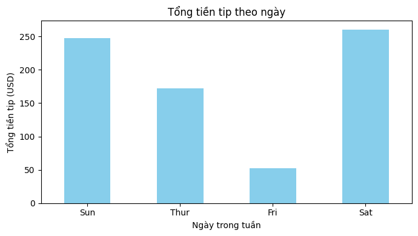

```python
import matplotlib.pyplot as plt

# 1. Vẽ đồ thị thể hiện tổng tiền tip theo ngày
tip_by_day_sum = df.groupby('day')['tip'].sum().reindex(['Sun', 'Mon', 'Tue', 'Wed', 'Thur', 'Fri', 'Sat']).dropna()
plt.figure(figsize=(7,4))
tip_by_day_sum.plot(kind='bar', color='skyblue')
plt.title('Tổng tiền tip theo ngày')
plt.xlabel('Ngày trong tuần')
plt.ylabel('Tổng tiền tip (USD)')
plt.xticks(rotation=0)
plt.tight_layout()
plt.show()
```

## Với Matplotlib

Bạn hãy trực quan với thư viện matplotlib

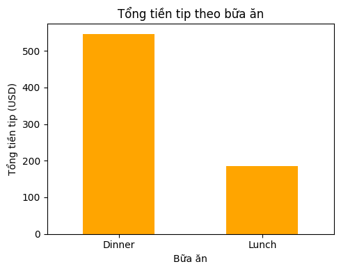

```python
# 2. Vẽ đồ thị thể hiện tổng tiền tip theo bữa ăn (time)
tip_by_time_sum = df.groupby('time')['tip'].sum()
plt.figure(figsize=(5,4))
tip_by_time_sum.plot(kind='bar', color='orange')
plt.title('Tổng tiền tip theo bữa ăn')
plt.xlabel('Bữa ăn')
plt.ylabel('Tổng tiền tip (USD)')
plt.xticks(rotation=0)
plt.tight_layout()
plt.show()
```

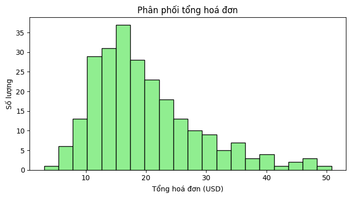

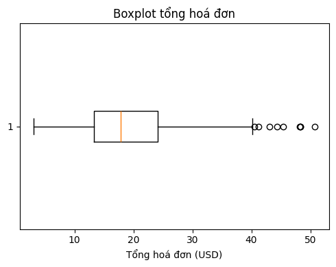

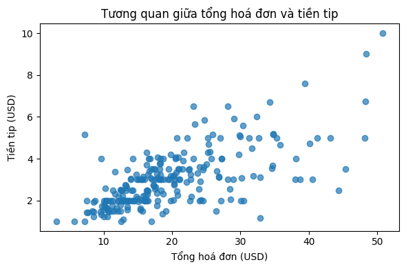

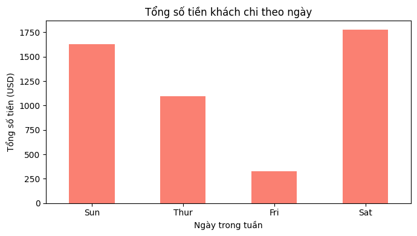

```python
# 3. Vẽ đồ thị histogram của tổng hoá đơn
plt.figure(figsize=(7,4))
plt.hist(df['total_bill'], bins=20, color='lightgreen', edgecolor='black')
plt.title('Phân phối tổng hoá đơn')
plt.xlabel('Tổng hoá đơn (USD)')
plt.ylabel('Số lượng')
plt.tight_layout()
plt.show()

# 4. Vẽ đồ thị boxplot của tổng hoá đơn
plt.figure(figsize=(5,4))
plt.boxplot(df['total_bill'], vert=False)
plt.title('Boxplot tổng hoá đơn')
plt.xlabel('Tổng hoá đơn (USD)')
plt.tight_layout()
plt.show()

# 5. Vẽ đồ thị kiểm tra sự liên quan giữa tổng hoá đơn và tiền tip
plt.figure(figsize=(6,4))
plt.scatter(df['total_bill'], df['tip'], alpha=0.7)
plt.title('Tương quan giữa tổng hoá đơn và tiền tip')
plt.xlabel('Tổng hoá đơn (USD)')
plt.ylabel('Tiền tip (USD)')
plt.tight_layout()
plt.show()

# 6. So sánh số tiền mà khách hàng đã chi giữa các ngày trong tuần
total_bill_by_day = df.groupby('day')['total_bill'].sum().reindex(['Sun', 'Mon', 'Tue', 'Wed', 'Thur', 'Fri', 'Sat']).dropna()
plt.figure(figsize=(7,4))
total_bill_by_day.plot(kind='bar', color='salmon')
plt.title('Tổng số tiền khách chi theo ngày')
plt.xlabel('Ngày trong tuần')
plt.ylabel('Tổng số tiền (USD)')
plt.xticks(rotation=0)
plt.tight_layout()
plt.show()
```

## Với Seaborn

Bạn hãy tìm hiểu và trực quan với thư viện seaborn

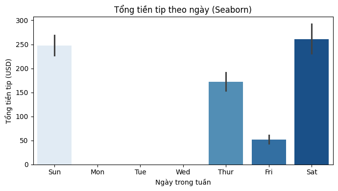

```python
import seaborn as sns

# 1. Vẽ tổng tiền tip theo ngày với seaborn
plt.figure(figsize=(7,4))
sns.barplot(data=df, x='day', y='tip', estimator=sum, order=['Sun', 'Mon', 'Tue', 'Wed', 'Thur', 'Fri', 'Sat'], palette='Blues')
plt.title('Tổng tiền tip theo ngày (Seaborn)')
plt.xlabel('Ngày trong tuần')
plt.ylabel('Tổng tiền tip (USD)')
plt.tight_layout()
plt.show()
```